# Tugas-Pertemuan-6

Rafi Adabhi Sunarya

2025-10-02

## 1. Packages

```r
library(rio)
library(ggplot2)
library(tsibble)
library(tseries)
library(MASS)
library(readr)
library(TSA)
library(forecast)
```

## 2. Import Data

```r
df <- read_csv("https://raw.githubusercontent.com/rafiadabhi/MPDW/main/Pertemuan%201/Data/crude_oil_clean_period_price.csv")
data <- df$price[255:382]
print(data)
```

```
##   [1]  39.88  37.05  43.80  42.12  49.64  51.76  49.13  43.45  48.20  51.75
##  [11]  55.40  49.72  51.97  56.50  60.57  68.94  66.24  59.76  57.32  61.04
##  [21]  67.92  61.41  66.63  71.88  71.29  73.93  74.40  70.26  62.91  58.73
##  [31]  63.13  61.05  58.14  61.79  65.87  65.71  64.01  70.68  78.21  74.04
##  [41]  81.66  94.53  88.71  95.98  91.75 101.84 101.58 113.46 127.35 140.00
##  [51] 124.08 115.46 100.64  67.81  54.43  44.60  41.68  44.76  49.66  51.12
##  [61]  66.31  69.89  69.45  69.96  70.61  77.00  77.28  79.36  72.89  79.66
##  [71]  83.76  86.15  73.97  75.63  78.95  71.92  79.97  81.43  84.11  91.38
##  [81]  92.19  96.97 106.72 113.93 102.70  95.42  95.70  88.81  79.20  93.19
##  [91] 100.36  98.83  98.48 107.07 103.02 104.87  86.53  84.96  88.06  96.47
## [101]  92.19  86.24  88.91  91.82  97.49  92.05  97.23  93.46  91.97  96.56
## [111] 105.03 107.65 102.33  96.38  92.72  98.42  97.49 102.59 101.58  99.74
## [121] 102.71 105.37  98.17  95.96  91.16  80.54  66.15  53.27
```

### 2.1 Karakteristik Data

```r
length(data)
```

```
## [1] 128
```

```r
head(data)
```

```
## [1] 39.88 37.05 43.80 42.12 49.64 51.76
```

```r
tail(data)
```

```
## [1] 98.17 95.96 91.16 80.54 66.15 53.27
```

```r
is.numeric(data)
```

```
## [1] TRUE
```

### 2.2 Data Spliting

```r
n <- length(data)          # total = 128
n_train <- floor(0.8 * n)  # 80% = 102

train_data <- data[1:n_train]
test_data  <- data[(n_train+1):n]

length(train_data)  # 102
```

```
## [1] 102
```

```r
length(test_data)   # 26
```

```
## [1] 26
```

## 3. Eksplorasi Data

### 3.1 Plot Data Penuh

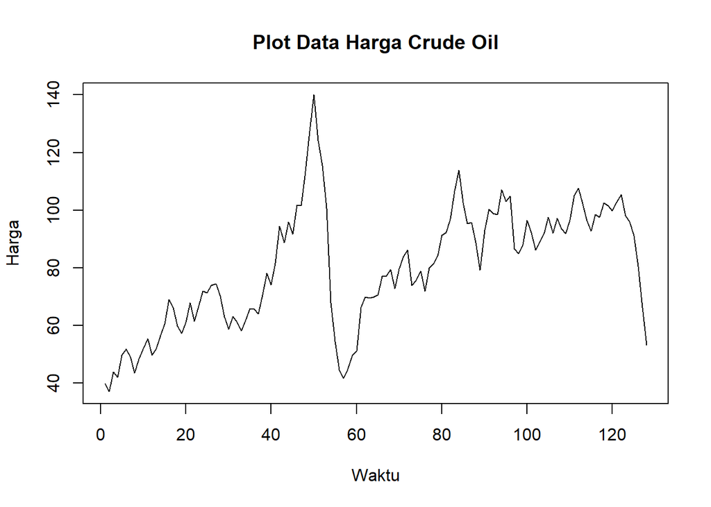

```r
plot.ts(data,
        lty = 1,
        xlab = "Waktu",
        ylab = "Harga",
        main = "Plot Data Harga Crude Oil")
```

### 3.2 Plot Data Latih

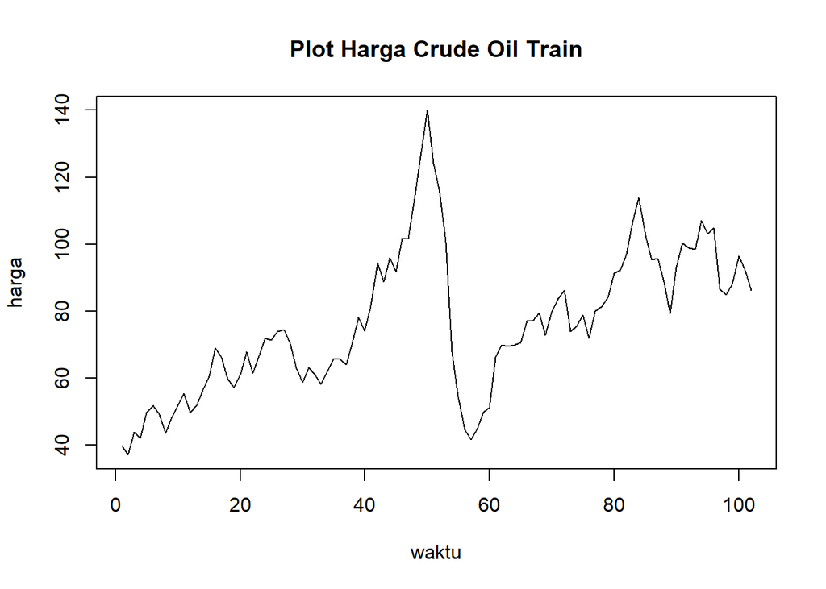

```r
plot.ts(train_data, lty=1, xlab="waktu", ylab="harga", main="Plot Harga Crude Oil Train")
```

### 3.3 Plot Data Uji

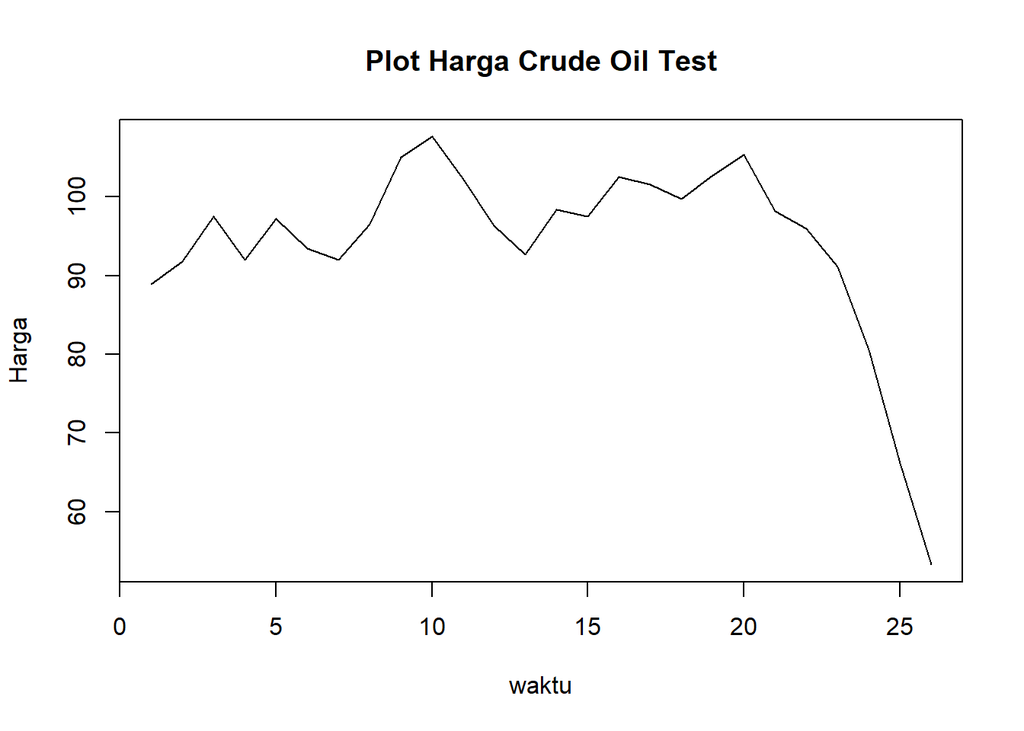

```r
plot.ts(test_data, lty=1, xlab="waktu", ylab="Harga", main="Plot Harga Crude Oil Test")
```

## 4. Uji Stasioneritas Data

### 4.1 Plot ACF

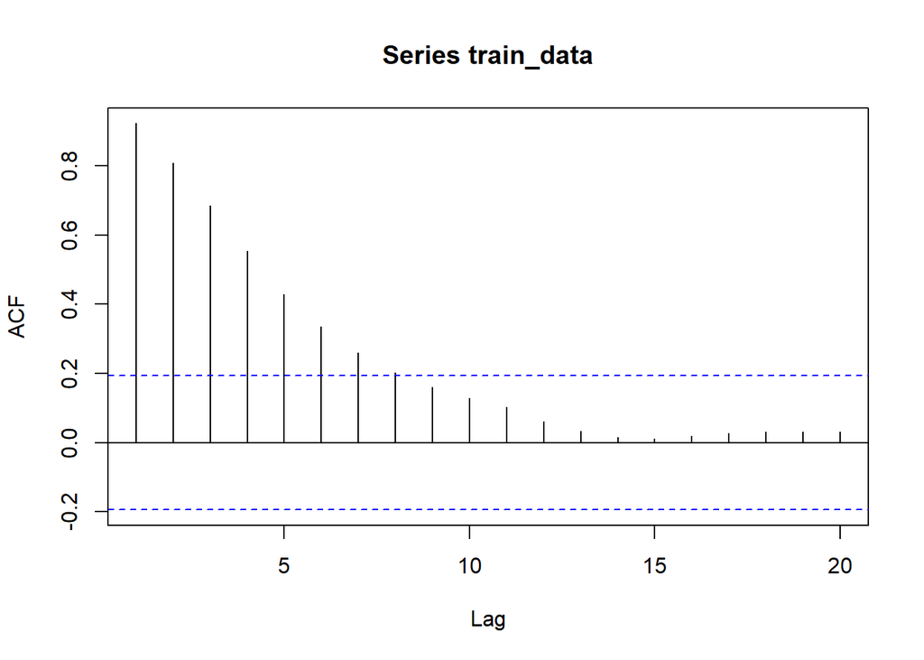

```r
acf(train_data)
```

Berdasarkan plot ACF, terlihat bahwa plot ACF data menurun secara perlahan (tails of slowly). Hal ini juga menjadi indikasi bahwa data tidak stasioner dalam rataan

### 4.2 Uji ADF

```r
tseries::adf.test(train_data)
```

```
##
##  Augmented Dickey-Fuller Test
##
## data:  train_data
## Dickey-Fuller = -3.7827, Lag order = 4, p-value = 0.02244
## alternative hypothesis: stationary
```

$H_0$ : Data tidak stasioner dalam rataan $H_1$ : Data stasioner dalam rataan

Berdasarkan uji ADF tersebut, didapat p-value sebesar 0.0224 yang lebih kecil dari taraf nyata 5% sehingga tolak $H_0$ dan menandakan bahwa data stasioner dalam rataan.Namun jika menggunakan taraf nyata 1% hipotesis nya tak tolak $H_0$, sehingga ada indikasi rataan tidak stasioner

### 4.3 Plot Box-Cox

```r
# Uji Box-Cox
index <- seq(1:102)
bc <- boxcox(
  train_data - min(train_data) + 1 ~ index,
  lambda = seq(0, 5, by = 0.001)
)
```

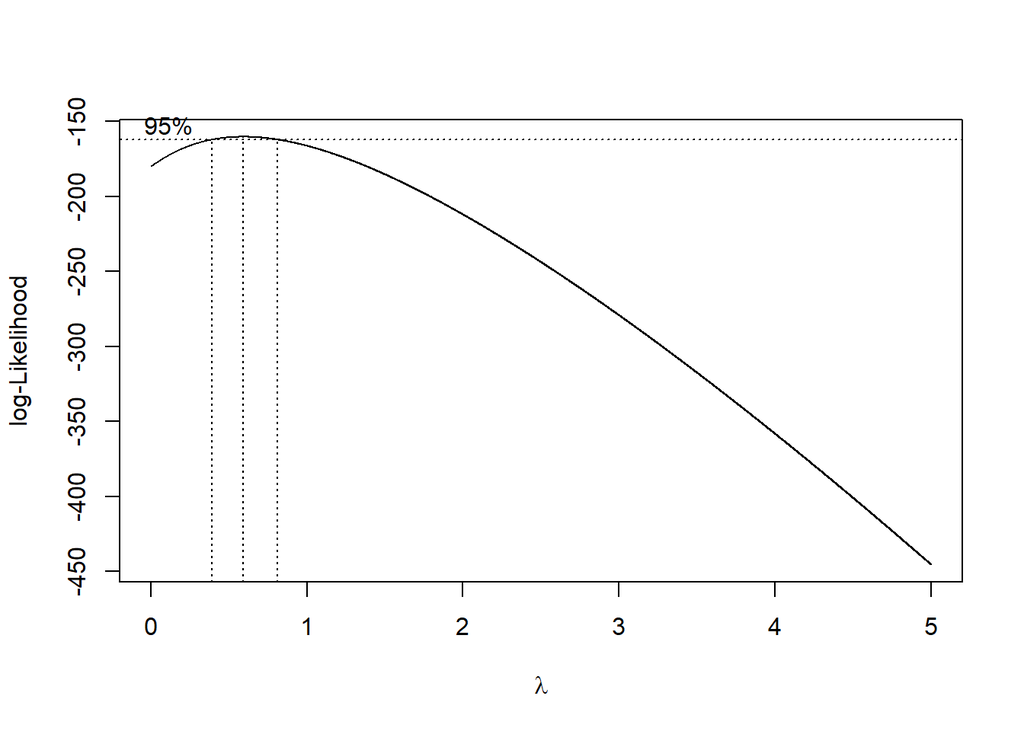

```r
# Nilai lambda optimum (dibulatkan)
lambda <- bc$x[which.max(bc$y)]
lambda
```

```
## [1] 0.592
```

```r
# Selang kepercayaan 95% untuk lambda
ci_lambda <- bc$x[bc$y > max(bc$y) - 0.5 * qchisq(0.95, 1)]

# Batas bawah dan batas atas
ci_lower <- min(ci_lambda)
ci_upper <- max(ci_lambda)

c(Batas_Bawah = ci_lower, Batas_Atas = ci_upper)
```

```
## Batas_Bawah  Batas_Atas
##       0.390       0.813
```

Hasil uji Box–Cox menunjukkan bahwa nilai λ optimum adalah 0,592 dengan interval kepercayaan 95% sebesar (0,390–0,813). Karena selang tersebut tidak memuat nilai λ = 1, maka dapat disimpulkan bahwa data tidak stasioner dalam ragam sehingga diperlukan transformasi.

## 5. Penanganan Stasioneritas Data

### 5.1 Transformasi Box-Cox

```r
# Data digeser agar positif
y_shift <- train_data - min(train_data) + 1

# Transformasi Box-Cox dengan lambda ~ 0.5 (akar kuadrat)
y_bc <- y_shift^0.5
```

```r
# Uji Box-Cox
bc <- boxcox(
  y_bc ~ index,
  lambda = seq(0, 5, by = 0.001)
)
```

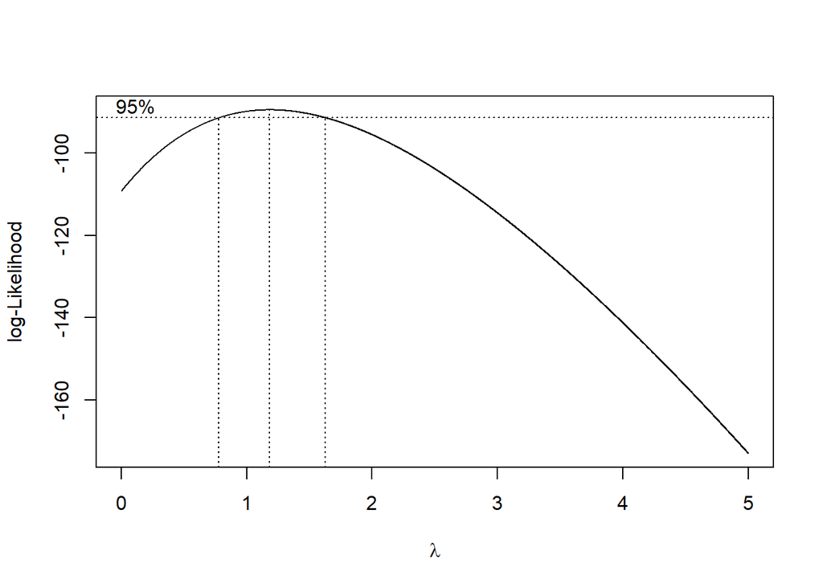

```r
# Nilai lambda optimum (dibulatkan)
lambda <- bc$x[which.max(bc$y)]
lambda
```

```
## [1] 1.183
```

```r
# Selang kepercayaan 95% untuk lambda
ci_lambda <- bc$x[bc$y > max(bc$y) - 0.5 * qchisq(0.95, 1)]

# Batas bawah dan batas atas
ci_lower <- min(ci_lambda)
ci_upper <- max(ci_lambda)

c(Batas_Bawah = ci_lower, Batas_Atas = ci_upper)
```

```
## Batas_Bawah  Batas_Atas
##       0.780       1.626
```

## 6. Identifikasi Model

### 6.1 Plot ACF untuk MA(q)

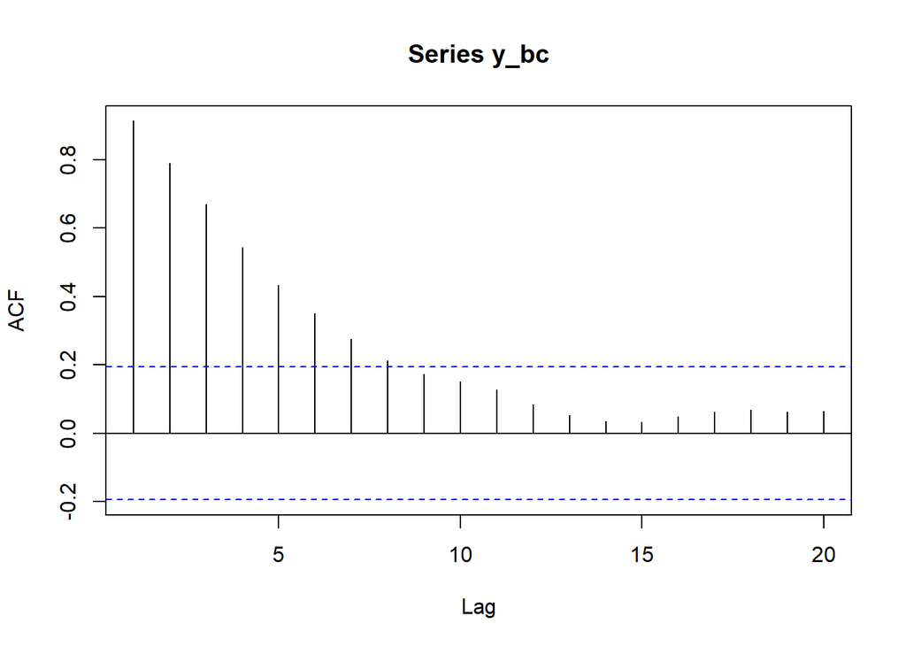

```r
acf(y_bc)
```

Berdasarkan plot tersebut, terlihat bahwa plot ACF cenderung tails off pada lag ke 8

### 6.2 Plot PACF untuk AR(p=)

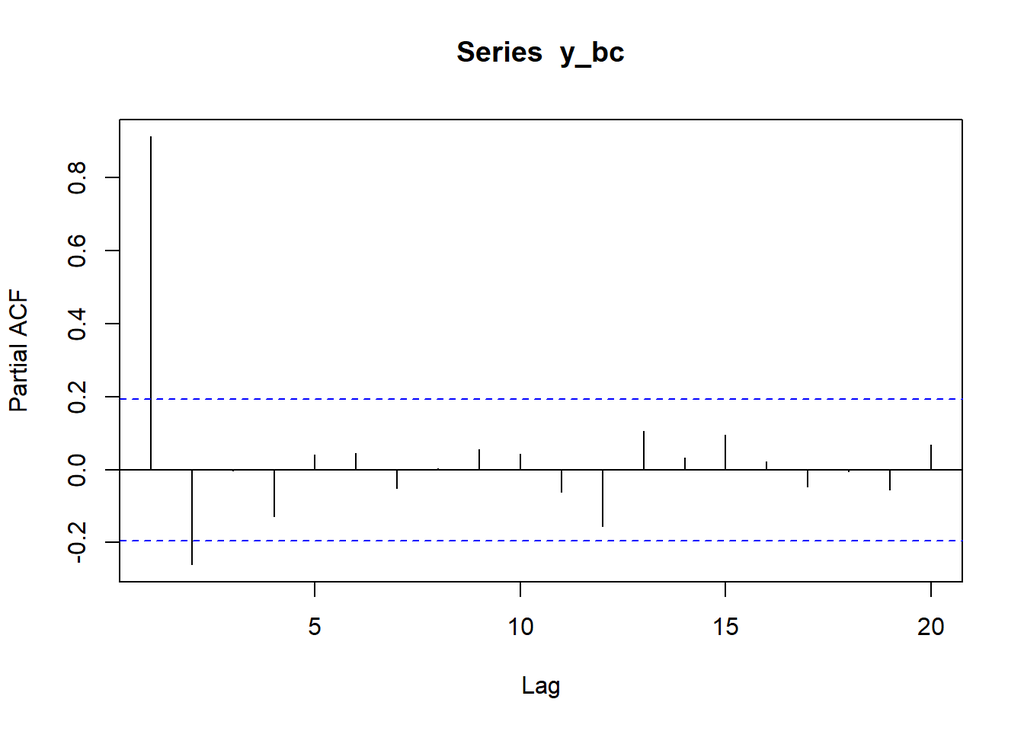

```r
pacf(y_bc)
```

Berdasarkan plot tersebut, terlihat bahwa plot PACF cenderung cuts off pada lag ke 2

```r
eacf(y_bc)
```

```
## AR/MA
##   0 1 2 3 4 5 6 7 8 9 10 11 12 13
## 0 x x x x x x x x o o o  o  o  o
## 1 x x o o o o o o o o o  o  o  o
## 2 x o o o o o o o o o o  o  o  o
## 3 x x o o o o o o o o o  o  o  o
## 4 x o o o o o o o o o o  o  o  o
## 5 x x x x o o o o o o o  o  o  o
## 6 o x x o o o o o o o o  o  o  o
## 7 o x x o o o o o o o o  o  o  o
```